# 2주차 패키지

위재성

## Chapter 1 모델링을 위한 데이터 전처리

### 문제0. (기본 세팅) 0번 txt파일을 실행하세요.

(패키지 불러오기, 디렉토리 설정)

```r
## 0번
setwd("C:/Users/위재성/Desktop/Psat/2학기/Package/2주차 패키지")
getwd()
```

```
## [1] "C:/Users/위재성/Desktop/Psat/2학기/Package/2주차 패키지"
```

```r
need_packages <- c("tidyverse", "ggplot2", "data.table", 'caret','randomForest', "progress", "xgboost", 'dummies','magrittr')
options(warn = -1)
for(i in 1:length(need_packages)){
  if(require(need_packages[i], character.only = T) == 0){
    install.packages(need_packages[i])
    require(need_packages[i], character.only = T)
  }
  else{require(need_packages[i], character.only = T)}
}
rm(list = ls())
```

### 문제1. Train데이터를 불러온 뒤 기본 구조를 파악하고 데이터 개수, 변수 개수, 데이터 형식을 확인해보세요.

```r
data = fread('data/train.csv')
data %>% head(3)
```

```
##    단지코드 총세대수 임대건물구분     지역 공급유형 전용면적 전용면적별세대수
## 1:    C2483      900       아파트 경상북도 국민임대    51.93               15
## 2:    C2483      900       아파트 경상북도 국민임대    51.93               41
## 3:    C2483      900       아파트 경상북도 국민임대    51.95               89
##    공가수 자격유형 임대보증금 임대료
## 1:     38        A   27304000 184330
## 2:     38        A   27304000 184330
## 3:     38        A   27304000 184330
##    도보 10분거리 내 지하철역 수(환승노선 수 반영)
## 1:                                              0
## 2:                                              0
## 3:                                              0
##    도보 10분거리 내 버스정류장 수 단지내주차면수 등록차량수
## 1:                              3           1425       1015
## 2:                              3           1425       1015
## 3:                              3           1425       1015
```

```r
data %>% glimpse()
```

```
## Rows: 2,457
## Columns: 15
## $ 단지코드                                         <chr> "C2483", "C2483", "C2483"~
## $ 총세대수                                         <int> 900, 900, 900, 900, 900, ~
## $ 임대건물구분                                     <chr> "아파트", "아파트", "아파트~
## $ 지역                                             <chr> "경상북도", "경상북도",~
## $ 공급유형                                         <chr> "국민임대", "국민임대", "~
## $ 전용면적                                         <dbl> 51.93, 51.93, 51.95, 51.9~
## $ 전용면적별세대수                                 <int> 15, 41, 89, 135, 86, 276, 60,~
## $ 공가수                                           <int> 38, 38, 38, 38, 38, 17, ~
## $ 자격유형                                         <chr> "A", "A", "A", "A", "A", ~
## $ 임대보증금                                       <chr> "27304000", "27304000", "2~
## $ 임대료                                           <chr> "184330", "184330", "184~
## $ `도보 10분거리 내 지하철역 수(환승노선 수 반영)` <int> 0, 0, 0, 0, 0, 0, 0, 0, 0, 0, 0, 1, 1, ~
## $ `도보 10분거리 내 버스정류장 수`                 <int> 3, 3, 3, 3, 3, 3, 3, 3, 3, 3, 3, ~
## $ 단지내주차면수                                   <int> 1425, 1425, 1425, 1425, 1425~
## $ 등록차량수                                       <int> 1015, 1015, 1015, 1015, 10~
```

```r
data %>% str()
```

```
## Classes 'data.table' and 'data.frame':   2457 obs. of  15 variables:
##  $ 단지코드                                      : chr  "C2483" "C2483" "C2483" "C2483" ...
##  $ 총세대수                                      : int  900 900 900 900 900 545 545 545 545 545 ...
##  $ 임대건물구분                                  : chr  "아파트" "아파트" "아파트" "아파트" ...
##  $ 지역                                          : chr  "경상북도" "경상북도" "경상북도" "경상북도" ...
##  $ 공급유형                                      : chr  "국민임대" "국민임대" "국민임대" "국민임대" ...
##  $ 전용면적                                      : num  51.9 51.9 52 52 59.9 ...
##  $ 전용면적별세대수                              : int  15 41 89 135 86 276 60 20 38 19 ...
##  $ 공가수                                        : int  38 38 38 38 38 17 17 17 17 17 ...
##  $ 자격유형                                      : chr  "A" "A" "A" "A" ...
##  $ 임대보증금                                    : chr  "27304000" "27304000" "27304000" "27304000" ...
##  $ 임대료                                        : chr  "184330" "184330" "184330" "184330" ...
##  $ 도보 10분거리 내 지하철역 수(환승노선 수 반영): int  0 0 0 0 0 0 0 0 0 0 ...
##  $ 도보 10분거리 내 버스정류장 수                : int  3 3 3 3 3 3 3 3 3 3 ...
##  $ 단지내주차면수                                : int  1425 1425 1425 1425 1425 624 624 624 624 624 ...
##  $ 등록차량수                                    : int  1015 1015 1015 1015 1015 205 205 205 205 205 ...
##  - attr(*, ".internal.selfref")=<externalptr>
```

```r
data %>% summary()
```

```
##    단지코드            총세대수      임대건물구분           지역
##  Length:2457        Min.   :  26.0   Length:2457        Length:2457
##  Class :character   1st Qu.: 514.0   Class :character   Class :character
##  Mode  :character   Median : 775.0   Mode  :character   Mode  :character
##                     Mean   : 884.1
##                     3rd Qu.:1099.0
##                     Max.   :2568.0
##
##    공급유형            전용면적      전용면적별세대수     공가수
##  Length:2457        Min.   : 12.62   Min.   :   1.0   Min.   : 0.00
##  Class :character   1st Qu.: 32.60   1st Qu.:  15.0   1st Qu.: 4.00
##  Mode  :character   Median : 39.93   Median :  63.0   Median :11.00
##                     Mean   : 44.84   Mean   : 104.3   Mean   :12.92
##                     3rd Qu.: 51.57   3rd Qu.: 146.0   3rd Qu.:20.00
##                     Max.   :583.40   Max.   :1865.0   Max.   :55.00
##
##    자격유형          임대보증금           임대료
##  Length:2457        Length:2457        Length:2457
##  Class :character   Class :character   Class :character
##  Mode  :character   Mode  :character   Mode  :character
##
##
##
##
##  도보 10분거리 내 지하철역 수(환승노선 수 반영) 도보 10분거리 내 버스정류장 수
##  Min.   :0.0000                                 Min.   : 0.000
##  1st Qu.:0.0000                                 1st Qu.: 2.000
##  Median :0.0000                                 Median : 3.000
##  Mean   :0.1787                                 Mean   : 3.671
##  3rd Qu.:0.0000                                 3rd Qu.: 4.000
##  Max.   :3.0000                                 Max.   :20.000
##  NA's   :179                                    NA's   :2
##  단지내주차면수     등록차량수
##  Min.   :  13.0   Min.   :  13.0
##  1st Qu.: 285.0   1st Qu.: 220.0
##  Median : 517.0   Median : 487.0
##  Mean   : 600.2   Mean   : 559.5
##  3rd Qu.: 817.0   3rd Qu.: 770.0
##  Max.   :1798.0   Max.   :2550.0
##
```

### 문제2. 각 데이터의 컬럼명을 확인해보세요. ‘도보 10분거리 내 지하철역 수(환승노선 수 반영)’ 컬럼이름과 ‘도보 10분거리 내 버스정류장 수’ 컬럼이름이 너무 길기에 각각 ‘지하철개수’, ‘버스개수’로 컬럼명을 바꾸어주세요.

```r
data %>% names()
```

```
##  [1] "단지코드"
##  [2] "총세대수"
##  [3] "임대건물구분"
##  [4] "지역"
##  [5] "공급유형"
##  [6] "전용면적"
##  [7] "전용면적별세대수"
##  [8] "공가수"
##  [9] "자격유형"
## [10] "임대보증금"
## [11] "임대료"
## [12] "도보 10분거리 내 지하철역 수(환승노선 수 반영)"
## [13] "도보 10분거리 내 버스정류장 수"
## [14] "단지내주차면수"
## [15] "등록차량수"
```

```r
data %<>%
  rename('지하철개수' = '도보 10분거리 내 지하철역 수(환승노선 수 반영)',
         '버스개수' = '도보 10분거리 내 버스정류장 수')
data %>% names() # 이름 변경 확인
```

```
##  [1] "단지코드"         "총세대수"         "임대건물구분"     "지역"
##  [5] "공급유형"         "전용면적"         "전용면적별세대수" "공가수"
##  [9] "자격유형"         "임대보증금"       "임대료"           "지하철개수"
## [13] "버스개수"         "단지내주차면수"   "등록차량수"
```

### 문제3. 각 데이터에 ‘임대료’, ‘임대보증금’이 문자형식으로 되어있습니다. 이유를 찾아 수치형으로 바꾸어 주세요. (HINT : NA 형식 확인)

NA형식 확인 결과 빈 문자열과 ’-’문자 존재함.

```r
# NA개수 확인
cat(' 임대료:' ,data %>% filter(임대료 %in% c('','-')) %>% nrow(),'\n',
    '임대보증금:',data %>% filter(임대보증금 %in% c('','-')) %>% nrow())
```

```
##  임대료: 486
##  임대보증금: 479
```

```r
data[,c('임대료','임대보증금')] %<>% mutate_if(is.character, as.numeric)

data[,c('임대료','임대보증금')] %>% is.na %>% colSums() # 확인결과 일치
```

```
##     임대료 임대보증금
##        486        479
```

### 문제4. 열별로 NA 개수를 확인해보세요. 확인한 후 다음과 같이 시각화해보세요.

```r
data %>% is.na %>% colSums # NA 개수 확인
```

```
##         단지코드         총세대수     임대건물구분             지역
##                0                0                0                0
##         공급유형         전용면적 전용면적별세대수           공가수
##                0                0                0                0
##         자격유형       임대보증금           임대료       지하철개수
##                0              479              486              179
##         버스개수   단지내주차면수       등록차량수
##                2                0                0
```

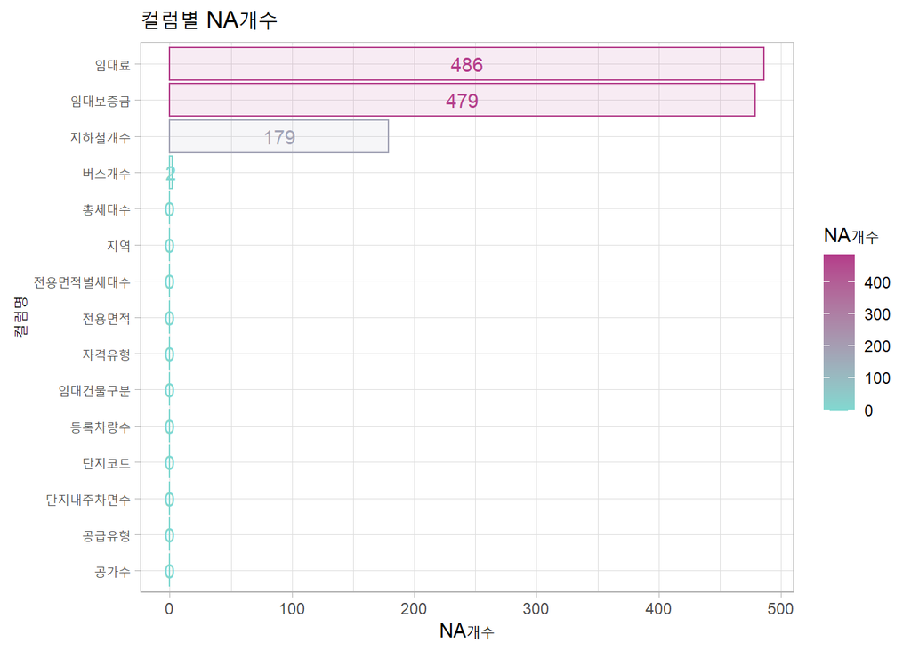

```r
# 열별 NA개수 데이터프레임 생성
na_data = data %>% is.na %>% colSums
na_data = data.frame(var = names(data), n = as.vector(na_data))

na_data %>%
  ggplot(aes(x = n, y = reorder(var,n), fill = n, color = n)) +
  geom_col(alpha = 0.1) +
  geom_text(aes(label = n), position = position_stack(vjust=0.5)) +

  # 테마 수정
  theme_light() +
  labs(title = '컬럼별 NA개수', x = 'NA개수', y = '컬럼명',
       fill = 'NA개수', color = 'NA개수') +
  scale_color_gradient(low = '#81D8D0', high = '#B43C8A') +
  scale_fill_gradient(low = '#81D8D0', high = '#B43C8A')
```

### 문제5. 데이터에서 범주형 변수를 Factor변수로, 정수형 변수를 수치형(Numeric)으로 바꾸어주세요.

```r
data %<>% mutate_if(is.character, as.factor)
data %<>% mutate_if(is.integer, as.numeric)
data %>% str() # 잘 바뀌었는지 확인
```

```
## Classes 'data.table' and 'data.frame':   2457 obs. of  15 variables:
##  $ 단지코드        : Factor w/ 420 levels "C1000","C1004",..: 355 355 355 355 355 369 369 369 369 369 ...
##  $ 총세대수        : num  900 900 900 900 900 545 545 545 545 545 ...
##  $ 임대건물구분    : Factor w/ 2 levels "상가","아파트": 2 2 2 2 2 2 2 2 2 2 ...
##  $ 지역            : Factor w/ 16 levels "강원도","경기도",..: 4 4 4 4 4 3 3 3 3 3 ...
##  $ 공급유형        : Factor w/ 10 levels "공공분양","공공임대(10년)",..: 6 6 6 6 6 6 6 6 6 6 ...
##  $ 전용면적        : num  51.9 51.9 52 52 59.9 ...
##  $ 전용면적별세대수: num  15 41 89 135 86 276 60 20 38 19 ...
##  $ 공가수          : num  38 38 38 38 38 17 17 17 17 17 ...
##  $ 자격유형        : Factor w/ 15 levels "A","B","C","D",..: 1 1 1 1 1 1 1 1 1 1 ...
##  $ 임대보증금      : num  27304000 27304000 27304000 27304000 30357000 ...
##  $ 임대료          : num  184330 184330 184330 184330 214270 ...
##  $ 지하철개수      : num  0 0 0 0 0 0 0 0 0 0 ...
##  $ 버스개수        : num  3 3 3 3 3 3 3 3 3 3 ...
##  $ 단지내주차면수  : num  1425 1425 1425 1425 1425 ...
##  $ 등록차량수      : num  1015 1015 1015 1015 1015 ...
##  - attr(*, ".internal.selfref")=<externalptr>
```

### 문제6. NA값이 있는 행을 확인한 후 NA값을 열 별 평균으로 대체해주세요.

```r
data %<>%
  lapply(function(x) replace_na(x, mean(x,na.rm=T))) %>%
  as.data.frame()

data %>% is.na %>% colSums() # NA값 모두 대체
```

```
##         단지코드         총세대수     임대건물구분             지역
##                0                0                0                0
##         공급유형         전용면적 전용면적별세대수           공가수
##                0                0                0                0
##         자격유형       임대보증금           임대료       지하철개수
##                0                0                0                0
##         버스개수   단지내주차면수       등록차량수
##                0                0                0
```

### 문제7. 공급 유형이 ‘장기전세’인 경우 임대료가 0입니다. 데이터가 잘못되어 있는 경우 확인하고 고쳐주세요.

```r
data %>%
  filter(공급유형 == '장기전세') # 공급유형 장기전세인 경우 확인
```

```
##   단지코드 총세대수 임대건물구분       지역 공급유형 전용면적 전용면적별세대수
## 1    C1397      370       아파트 서울특별시 장기전세    23.32               51
## 2    C1397      370       아파트 서울특별시 장기전세    46.79                4
## 3    C1397      370       아파트 서울특별시 장기전세    46.91               69
## 4    C1397      370       아파트 서울특별시 장기전세    51.96               24
## 5    C1397      370       아파트 서울특별시 장기전세    51.99               80
## 6    C1039      790       아파트 서울특별시 장기전세    59.88               49
## 7    C1039      790       아파트 서울특별시 장기전세    59.94               75
##   공가수 자격유형 임대보증금 임대료 지하철개수 버스개수 단지내주차면수
## 1      9        A   87444000 195294          0        3           1590
## 2      9        A  174888000 195294          0        3           1590
## 3      9        A  174888000 195294          0        3           1590
## 4      9        A  194562000 195294          0        3           1590
## 5      9        A  194562000 195294          0        3           1590
## 6     13        A  213863000 195294          0        3            673
## 7     13        A  213863000 195294          0        3            673
##   등록차량수
## 1       1595
## 2       1595
## 3       1595
## 4       1595
## 5       1595
## 6        645
## 7        645
```

```r
# 7개 행 모두 잘못됐으므로 0으로 변경
data[data['공급유형'] == '장기전세','임대료'] = 0

data %>%
  filter(공급유형 == '장기전세') # 확인!
```

```
##   단지코드 총세대수 임대건물구분       지역 공급유형 전용면적 전용면적별세대수
## 1    C1397      370       아파트 서울특별시 장기전세    23.32               51
## 2    C1397      370       아파트 서울특별시 장기전세    46.79                4
## 3    C1397      370       아파트 서울특별시 장기전세    46.91               69
## 4    C1397      370       아파트 서울특별시 장기전세    51.96               24
## 5    C1397      370       아파트 서울특별시 장기전세    51.99               80
## 6    C1039      790       아파트 서울특별시 장기전세    59.88               49
## 7    C1039      790       아파트 서울특별시 장기전세    59.94               75
##   공가수 자격유형 임대보증금 임대료 지하철개수 버스개수 단지내주차면수
## 1      9        A   87444000      0          0        3           1590
## 2      9        A  174888000      0          0        3           1590
## 3      9        A  174888000      0          0        3           1590
## 4      9        A  194562000      0          0        3           1590
## 5      9        A  194562000      0          0        3           1590
## 6     13        A  213863000      0          0        3            673
## 7     13        A  213863000      0          0        3            673
##   등록차량수
## 1       1595
## 2       1595
## 3       1595
## 4       1595
## 5       1595
## 6        645
## 7        645
```

### 문제8. 면적당 임대료 면적당 임대보증금을 계산하여 파생변수를 만들어주세요.

```r
data %<>%
  mutate(면적당임대료 = 임대료 / 전용면적,
         면적당임대보증금 = 임대보증금 / 전용면적)

data %>% head(3)
```

```
##   단지코드 총세대수 임대건물구분     지역 공급유형 전용면적 전용면적별세대수
## 1    C2483      900       아파트 경상북도 국민임대    51.93               15
## 2    C2483      900       아파트 경상북도 국민임대    51.93               41
## 3    C2483      900       아파트 경상북도 국민임대    51.95               89
##   공가수 자격유형 임대보증금 임대료 지하철개수 버스개수 단지내주차면수
## 1     38        A   27304000 184330          0        3           1425
## 2     38        A   27304000 184330          0        3           1425
## 3     38        A   27304000 184330          0        3           1425
##   등록차량수 면적당임대료 면적당임대보증금
## 1       1015     3549.586         525784.7
## 2       1015     3549.586         525784.7
## 3       1015     3548.219         525582.3
```

### 문제9. 임대료, 임대보증금, 단지코드는 모델링에 사용하지 않을 예정입니다. 삭제해주세요.

```r
data %<>% select(-c('임대료','임대보증금','단지코드'))
```

## Chapter 2 랜덤포레스트 및 교차검증

### 문제1. 데이터를 층화추출을 사용하여 Train셋와 Validation셋을 7:3 비율로 나누어주세요.

(Seed : 2728 / p = 0.7 )

```r
set.seed(2728)
# createDataPartiotion에서 자동으로 층화추출
train_idx = createDataPartition(data$등록차량수, p = 0.7, list=F)
train = data[train_idx,]
valid = data[-train_idx,]
```

### 문제2. 랜덤포레스트의 하이퍼 파라미터에 대해서 간단히 적어주세요.

`max_depth`: 트리의 최대 깊이 지정, 깊어질수록 과적할 될 가능성 증가  
`n_estimators`: 결정트리의 갯수, 커질수록 성능이 좋아지지만 모델링 시간이 오래걸림.  
`min_samples_split`: 과적합 제어용도, 노드를 분할하기 위한 최소의 샘플 데이터 수

### 문제3. 그리드서치를 위해 다음과 같이 데이터 프레임을 만들어 주세요.

(For문을통해 모델링을 진행할 과정입니다.) (HINT : expand.grid 함수)

```r
param = expand.grid(mtry = seq(5,8),
                    ntree = seq(200,400,by=100),
                    RMSE = NA)

param
```

```
##    mtry ntree RMSE
## 1     5   200   NA
## 2     6   200   NA
## 3     7   200   NA
## 4     8   200   NA
## 5     5   300   NA
## 6     6   300   NA
## 7     7   300   NA
## 8     8   300   NA
## 9     5   400   NA
## 10    6   400   NA
## 11    7   400   NA
## 12    8   400   NA
```

#### 문제4. For문을 활용하여 등록차량수를 예측하는 랜덤포레스트 모델링을 진행한 후

Validation셋의 RMSE를 계산하여 앞서 만들었던 표에 RMSE값을 넣으세요.

```r
for (i in seq(1:nrow(param))){
  ntree = param[i,'ntree']
  mtry = param[i,'mtry']

  set.seed(2728)

  # 랜덤 포레스트 모델링
  rf = randomForest(등록차량수 ~ ., data = train,
                    mtry = mtry, ntree = ntree)

  # 예측값 생성
  pred = predict(rf,valid)

  # RMSE계산
  param[i,"RMSE"] = RMSE(pred,valid$등록차량수)

}
```

### 문제5. (기존 필수/신입선택) 결과를 다음과 같이 시각화 하고, 간단히 해석해보세요.

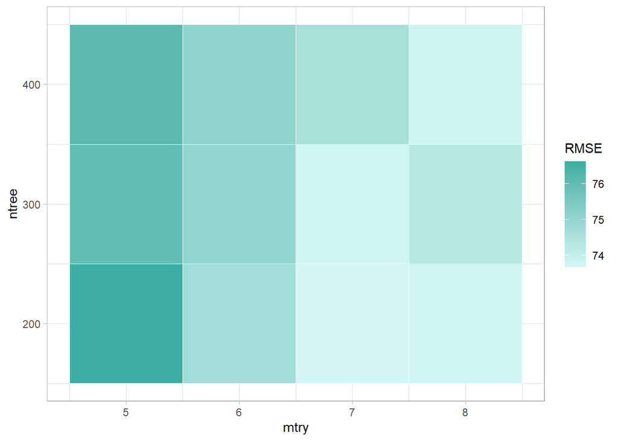

```r
param %>%
  ggplot(aes(x = mtry, y = ntree, fill = RMSE)) +
  geom_tile(color='white') +

  # 테마 수정
  theme_light() +
  scale_fill_gradient(low = '#D2F7F4', high = '#3CAEA3')
```

### 문제6. RMSE가 가장 낮은 하이퍼 파라미터 조합을 출력하세요.

```r
param %>% filter(RMSE == min(RMSE))
```

```
##   mtry ntree     RMSE
## 1    7   200 73.68469
```

### 문제7. 5-fold 교차검증을 위해 층화추출을 사용하여 CV인덱스를 만들어주세요.

(Seed : 2728)

```r
set.seed(2728)
cv_idx = createFolds(data$등록차량수, k=5, list=F)
```

### 문제8. 그 리드서치를 위해 다음과 같이 데이터 프레임을 만들어 주세요.

(For문을 통해 모델링을 진행할 과정입니다.) (HINT : expand.grid 함수)

```r
param_cv = expand.grid(mtry = seq(5,8),
                       ntree = seq(200,400,by=100),
                       RMSE = NA)

param_cv
```

```
##    mtry ntree RMSE
## 1     5   200   NA
## 2     6   200   NA
## 3     7   200   NA
## 4     8   200   NA
## 5     5   300   NA
## 6     6   300   NA
## 7     7   300   NA
## 8     8   300   NA
## 9     5   400   NA
## 10    6   400   NA
## 11    7   400   NA
## 12    8   400   NA
```

### 문제9. 이중 For문을 활용하여 등록차량수를 예측하는 랜덤포레스트 모델링을

진행한 후 Validation셋의 RMSE를 계산하여 앞서 만들었던 표에 RMSE를 넣으세요. (HINT : 첫번째 For문 – 하이퍼 파라미터 변경 / 두번째 For문 – Val셋 변경)

```r
rmse = NA # fold별 rmse 저장할 변수 생성
for (i in seq(1:nrow(param_cv))){
  # 파라미터 생성
  ntree = param_cv[i,'ntree']
  mtry = param_cv[i,'mtry']

  for (n in seq(1:5)){
    # fold에 맞게 train,valid set 생성
    train = data[cv_idx != n,]
    valid = data[cv_idx == n,]

    # 랜덤 포레스트 모델링
    set.seed(2728)
    rf = randomForest(등록차량수 ~ ., data = train,
                      mtry = mtry, ntree = ntree)

    # 예측값 생성
    pred = predict(rf,valid)
    rmse[n] = RMSE(pred,valid$등록차량수)

  }
  # fold별 평균 RMSE 계산
  param_cv[i,"RMSE"] = sum(rmse) / 5
}
```

### 문제10. (기존 필수/신입선택) 결과를 다음과 같이 시각화하고, 간단히 해석해보세요.

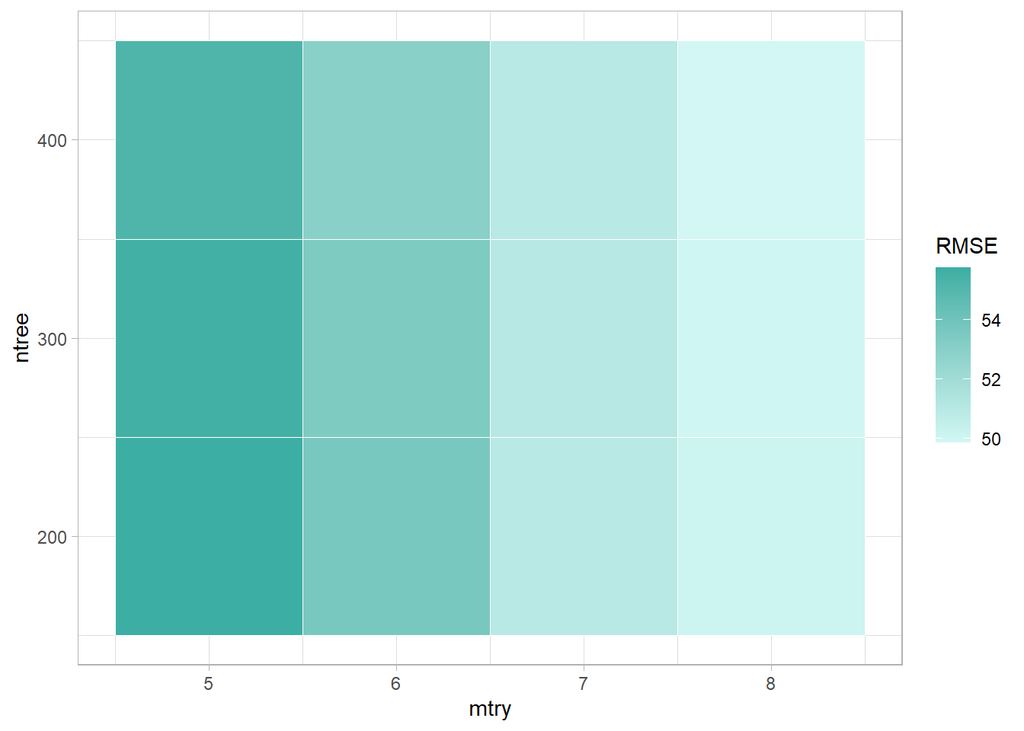

```r
param_cv %>%
  ggplot(aes(x = mtry, y = ntree, fill = RMSE)) +
  geom_tile(color='white') +

  # 테마 수정
  theme_light() +
  scale_fill_gradient(low = '#D2F7F4', high = '#3CAEA3')
```

좀 더 명확하게 mtry가 높을수록 ntree도 높을수록 RMSE가 줄어드는 것 확인.

### 문제11. RMSE가 가장 낮은 하이퍼 파라미터 조합을 출력하세요.

```r
param_cv %>% filter(RMSE == min(RMSE))
```

```
##   mtry ntree     RMSE
## 1    8   400 49.87055
```

### 문제12. 앞에서 Hold-out을 사용하여 튜닝한 결과와 5-fold CV를 사용하여 튜닝한 결과를 다음과 같이 시각화 하고 해석해주세요.

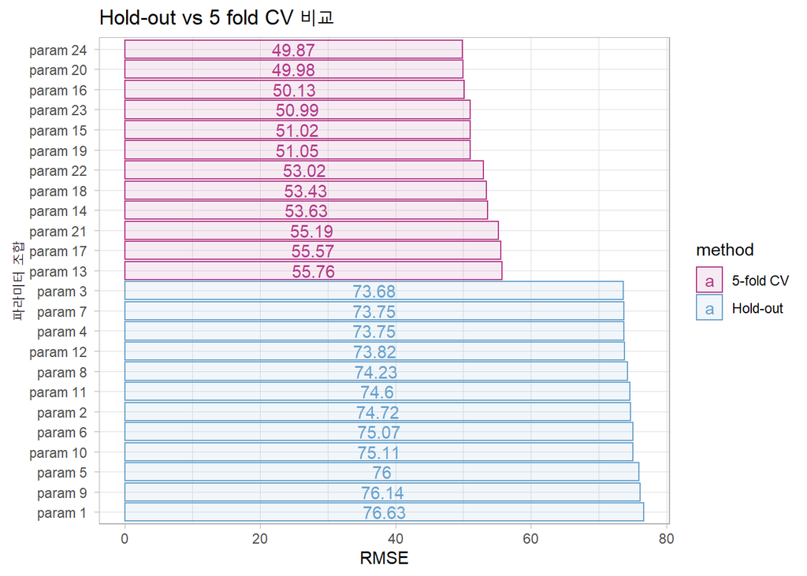

```r
# 각 결과 데이터에 method변수 생성
param %<>% mutate(method = 'Hold-out')
param_cv %<>% mutate(method = '5-fold CV')

rbind(param,param_cv) %>% # rbind통해 결과 데이터 결합
  ggplot(aes(x=RMSE, y=reorder(paste('param',1:24,by=''),-RMSE),
             fill = method, color = method)) +
  geom_col(alpha=0.1) +
  geom_text(aes(label=round(RMSE,2)), position = position_stack(vjust=0.5)) +

  # 테마 수정
  theme_light() +
  labs(title = 'Hold-out vs 5 fold CV 비교',
       y = '파라미터 조합') +
  scale_fill_manual(values = c('#B43C8A','#6AA2CD')) +
  scale_color_manual(values = c('#B43C8A','#6AA2CD'))
```

5-fold cv가 Hold-out 방법보다 RMSE가 더 낮게 나옴.

### 문제13. 랜덤포레스트에서 Importance계산이 어떻게 되는지 간단하게 적어주세요.

각 트리의 분기점에서 중요도 계산 후 평균 낸 값이 곧 mean gini decrease.  
높을수록 불순도가 크게 감소한다는 걸 의미하기 때문에 중요하다라고 해석.

## Chapter 3. XGBoost

### 문제1. Xgboost는 numeric 변수만 받으므로 범주형 변수를 encoding을 해야합니다. 범주형 변수들을 One-hot 인코딩해주세요.

```r
data_xgb = data %>% dummy.data.frame() # 더미 데이터 생성
data_xgb %>% str() # 결과 확인
```

```
## 'data.frame':    2457 obs. of  53 variables:
##  $ 총세대수              : num  900 900 900 900 900 545 545 545 545 545 ...
##  $ 임대건물구분상가      : int  0 0 0 0 0 0 0 0 0 0 ...
##  $ 임대건물구분아파트    : int  1 1 1 1 1 1 1 1 1 1 ...
##  $ 지역강원도            : int  0 0 0 0 0 0 0 0 0 0 ...
##  $ 지역경기도            : int  0 0 0 0 0 0 0 0 0 0 ...
##  $ 지역경상남도          : int  0 0 0 0 0 1 1 1 1 1 ...
##  $ 지역경상북도          : int  1 1 1 1 1 0 0 0 0 0 ...
##  $ 지역광주광역시        : int  0 0 0 0 0 0 0 0 0 0 ...
##  $ 지역대구광역시        : int  0 0 0 0 0 0 0 0 0 0 ...
##  $ 지역대전광역시        : int  0 0 0 0 0 0 0 0 0 0 ...
##  $ 지역부산광역시        : int  0 0 0 0 0 0 0 0 0 0 ...
##  $ 지역서울특별시        : int  0 0 0 0 0 0 0 0 0 0 ...
##  $ 지역세종특별자치시    : int  0 0 0 0 0 0 0 0 0 0 ...
##  $ 지역울산광역시        : int  0 0 0 0 0 0 0 0 0 0 ...
```

[output cut: 44 more lines]

### 문제2. Xgboost의 하이퍼 파라미터에 대해 간단히 적어주세요.

`max_depth` : 트리의 최대 깊이  
`min_child_weight`: 새 노드를 만들 때 필요한 최소 가중치 지정, 과적합 방지  
`subsample`: 행 샘플링 비율 지정, 모형에 사용될 임의 표본수 비율로 지정, 과적합 제어  
`colsample_bytree`: 열 샘플링 비율 지정, 모형에 사용될 변수갯수 비율로 지정, 마찬가지로 과적합 제어  
`eta`: learning rate 학습률  
`early_stopping_rounds`: 더 이상 평가 지표가 향상되지 않을 때의 최대 반복 횟수

### 문제3. 랜덤튜닝을 활용하여 튜닝을 진행할 예정입니다. 아래의 튜닝데이터 범위를 참고하여 서치할 하이퍼 파라미터를 골라주세요. (Seed : 2728)

```r
param_xgb = expand.grid(max_depth = seq(4,10),
                        min_child_weight = seq(4,10),
                        subsample = seq(0.5,1,by=0.1),
                        colsample_bytree = seq(0.5,1,by=0.1),
                        RMSE = NA)
set.seed(2728)
param_xgb %<>% sample_n(12) # 12개의 조합 랜덤 샘플링
```

### 문제4. 이중 For문을 활용하여 등록차량수를 예측하는 Xgboost 회귀모델링을 진행한 후 Validation의 RMSE를 계산해주세요.

(HINT : 첫번째 For문 – 파라미터 변경 / 두번째 For문 – Val셋 변경)

```r
rmse = NA # fold별 RMSE값 저장할 변수 생성
for (i in seq(1:nrow(param_xgb))){
  # 파라미터 값 생성
  max_depth = param_xgb[i,'max_depth']
  min_child_weight = param_xgb[i,'min_child_weight']
  subsample = param_xgb[i,'subsample']
  colsample_bytree = param_xgb[i,'colsample_bytree']

  param_list = list(max_depth = max_depth, min_child_weight = min_child_weight,
                    subsample = subsample, colsample_bytree = colsample_bytree)

  for (n in seq(1:5)){
    # fold별 train,valid set 생성
    train = data_xgb[cv_idx != n,]
    valid = data_xgb[cv_idx == n,]

    set.seed(2728)
    # XGBoost에 사용할 데이터 생성
    dtrain = xgb.DMatrix(data = train %>% select(-등록차량수) %>% as.matrix,
                         label = train$등록차량수)
    dvalid = xgb.DMatrix(data = valid %>% select(-등록차량수) %>% as.matrix,
                         label = valid$등록차량수)

    # 모델링~
    xgb = xgboost(dtrain, param = param_list,
                  eta = 0.01, nrounds = 1000,
                  early_stopping_rounds = 0.05*1000, verbose = 0)

    # 예측값 생성
    pred = predict(xgb,dvalid)
    rmse[n] = RMSE(pred,valid$등록차량수)

  }
  # fold별 평균 RMSE계산
  param_xgb[i,"RMSE"] = sum(rmse) / 5
}
```

### 문제5. 결과를 다음과 같이 시각화하고 가장 좋은 하이퍼 파라미터 조합을 보여주세요. 그리드서치와 랜덤서치의 개념, 그리고 랜덤 서치가 가지는 장점과 단점을 설명해주세요.

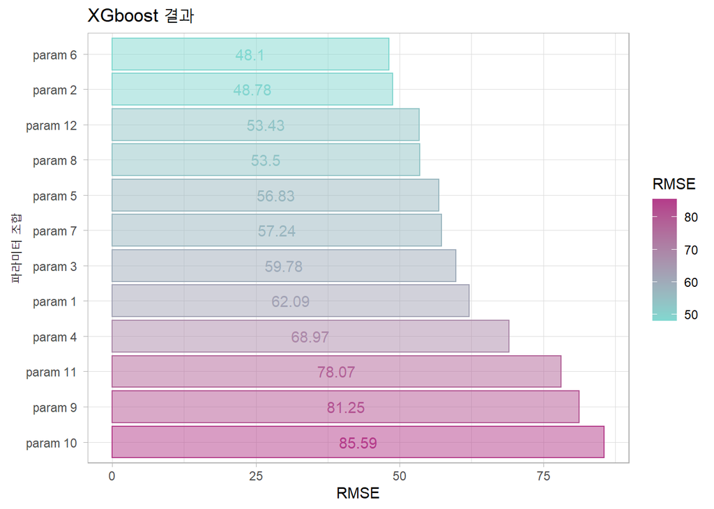

```r
param_xgb %>%
  ggplot(aes(x=RMSE, y=reorder(paste('param',1:12,by=''),-RMSE),
                               color = RMSE, fill = RMSE)) +
  geom_col(alpha = 0.5) +
  geom_text(aes(label = round(RMSE,2)), position = position_stack(vjust=0.5)) +

  # 테마 수정
  theme_light() +
  labs(title = 'XGboost 결과', y = '파라미터 조합') +
  scale_fill_gradient(low = '#81D8D0', high = '#B43C8A') +
  scale_color_gradient(low = '#81D8D0', high = '#B43C8A')
```

```r
param_xgb %>% filter(RMSE == min(RMSE))
```

```
##   max_depth min_child_weight subsample colsample_bytree     RMSE
## 1         8                4       0.9              0.6 48.09761
```

`grid search`: 하이퍼 파라미터 값들을 사전에 지정, 지정한 값들의 조합으로만 최적의 조합 탐색.  
`random search`: 하이퍼 파라미터 값들의 범위 지정, 범위 속에서 지정한 횟수만큼 최적의 조합 탐색.  
`장점`: `grid search`에 비해 탐색 시간이 짧음.  
`단점`: 랜덤하게 검색하다보니 최적의 값이 아닐 수 있음.

## Chapter 4 비교

### 문제 1. Test셋을 불러와 Train셋과 똑같이 전처리 해주세요.

```r
rm(list = ls()) # R과부화로 인해 기존 데이터 삭제

# train 데이터 전처리
train = fread('data/train.csv')
train %<>%
  rename('지하철개수' = '도보 10분거리 내 지하철역 수(환승노선 수 반영)',
         '버스개수' = '도보 10분거리 내 버스정류장 수')
train[,c('임대료','임대보증금')] %<>% mutate_if(is.character, as.numeric)

train %<>% mutate_if(is.character, as.factor)
train %<>% mutate_if(is.integer, as.numeric)

train %<>%
  lapply(function(x) replace_na(x, mean(x,na.rm=T))) %>%
  as.data.frame()

train[train['공급유형'] == '장기전세','임대료'] = 0

train %<>%
  mutate(면적당임대료 = 임대료 / 전용면적,
         면적당임대보증금 = 임대보증금 / 전용면적)

train %<>% select(-c('임대료','임대보증금','단지코드'))
train %>% head(3) # 전처리 결과 확인
```

```
##   총세대수 임대건물구분     지역 공급유형 전용면적 전용면적별세대수 공가수
## 1      900       아파트 경상북도 국민임대    51.93               15     38
## 2      900       아파트 경상북도 국민임대    51.93               41     38
## 3      900       아파트 경상북도 국민임대    51.95               89     38
##   자격유형 지하철개수 버스개수 단지내주차면수 등록차량수 면적당임대료
## 1        A          0        3           1425       1015     3549.586
## 2        A          0        3           1425       1015     3549.586
## 3        A          0        3           1425       1015     3548.219
##   면적당임대보증금
## 1         525784.7
## 2         525784.7
## 3         525582.3
```

```r
train %>% is.na %>% colSums # NA값 확인
```

```
##         총세대수     임대건물구분             지역         공급유형
##                0                0                0                0
##         전용면적 전용면적별세대수           공가수         자격유형
##                0                0                0                0
##       지하철개수         버스개수   단지내주차면수       등록차량수
##                0                0                0                0
##     면적당임대료 면적당임대보증금
##                0                0
```

```r
# test 데이터 전처리
test = fread('data/test.csv')
test %<>%
  rename('지하철개수' = '도보 10분거리 내 지하철역 수(환승노선 수 반영)',
         '버스개수' = '도보 10분거리 내 버스정류장 수')
test[,c('임대료','임대보증금')] %<>% mutate_if(is.character, as.numeric)

test %<>% mutate_if(is.character, as.factor)
test %<>% mutate_if(is.integer, as.numeric)

test %<>%
  lapply(function(x) replace_na(x, mean(x,na.rm=T))) %>%
  as.data.frame()

test[test['공급유형'] == '장기전세','임대료'] = 0

test %<>%
  mutate(면적당임대료 = 임대료 / 전용면적,
         면적당임대보증금 = 임대보증금 / 전용면적)

test %<>% select(-c('임대료','임대보증금','단지코드'))
test %>% head(3) # 전처리 결과 확인
```

```
##   총세대수 임대건물구분     지역 공급유형 전용면적 전용면적별세대수 공가수
## 1      900       아파트 경상북도 국민임대    39.72              134     38
## 2      900       아파트 경상북도 국민임대    39.72               15     38
## 3      900       아파트 경상북도 국민임대    51.93              385     38
##   자격유형 지하철개수 버스개수 단지내주차면수 등록차량수 면적당임대료
## 1        A          0        3           1425       1015     2610.272
## 2        A          0        3           1425       1015     2610.272
## 3        A          0        3           1425       1015     3549.586
##   면적당임대보증금
## 1         394436.1
## 2         394436.1
## 3         525784.7
```

```r
test %>% is.na %>% colSums # NA값 확인
```

```
##         총세대수     임대건물구분             지역         공급유형
##                0                0                0                0
##         전용면적 전용면적별세대수           공가수         자격유형
##                0                0                0                0
##       지하철개수         버스개수   단지내주차면수       등록차량수
##                0                0                0                0
##     면적당임대료 면적당임대보증금
##                0                0
```

### 문제2. RandomForest에서 가장 잘 나온 하이퍼 파라미터 조합을 사용하여 전체 Train셋을 학습시킨 후 Test셋에 대한 RMSE를 계산하세요.

```r
set.seed(2728)
rf = randomForest(등록차량수 ~ ., data = train,
                  mtry = 8, ntree = 400, importance=F)
pred = predict(rf,test)
rmse_RF = RMSE(pred,test$등록차량수)
rmse_RF
```

```
## [1] 30.98109
```

### 문제3. Xgboost에서 가장 잘 나온 하이퍼 파라미터 조합을 사용하여 전체 Train셋을 학습시킨 후 Test셋에 대한 RMSE를 계산하세요.

```r
test_xgb = test %>% dummy.data.frame()
train_xgb = train %>% dummy.data.frame()

param_list = list(max_depth = 8, min_child_weight = 4,
                    subsample = 0.9, colsample_bytree = 0.6)

set.seed(2728)
dtrain = xgb.DMatrix(data = train_xgb[,-51] %>% as.matrix,
                     label = train_xgb[,51])
dtest = xgb.DMatrix(data = test_xgb[,-51] %>% as.matrix,
                     label = test_xgb[,51])

xgb = xgboost(dtrain, param = param_list,
              eta = 0.01, nrounds = 1000,
              early_stopping_rounds = 0.05*1000, verbose = 1)
```

```
## Will train until train_rmse hasn't improved in 50 rounds.
##
```

```r
pred = predict(xgb,dtest)
rmse_XGB = RMSE(pred,test$등록차량수)
rmse_XGB
```

```
## [1] 34.27267
```

### 문제4. 2개의 모델링 결과를 다음과 같이 시각화한 후 해석해보세요.

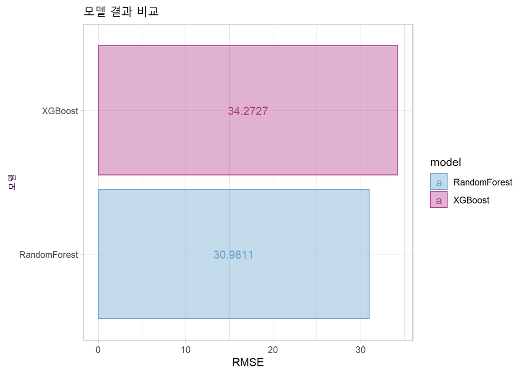

```r
result = data.frame(model = c('RandomForest','XGBoost'),
                    RMSE = c(rmse_RF,rmse_XGB))

result %>%
  ggplot(aes(x = RMSE, y = model, color = model, fill = model)) +
  geom_col(alpha = 0.4) +
  geom_text(aes(label = round(RMSE,4)), position = position_stack(vjust = 0.5)) +
  theme_light() +
  labs(title = '모델 결과 비교', y = '모델') +
  scale_fill_manual(values = c('#6AA2CD','#B43C8A')) +
  scale_color_manual(values = c('#6AA2CD','#B43C8A'))
```

하이퍼파라미터 튜닝 결과 RMSE를 기준으로 `RandomForest`모델의 성능이 더 높게 나온 것 확인.